# Week 5 JavaScript

## Week 5: JavaScript Part 1

### 1. What is JavaScript (JS)

JavaScript is a scripting language used to create dynamic content on web pages. It can interact with HTML and CSS to enhance user experiences

JS code is between `<script>` and `</script>` tags

### 2. Code editor

[figure not shown]

### 3. Writing a JavaScript Program

- Scripts can be placed in the `<body>`, or in the `<head>` section of an HTML page
- JS is better to put at the end of `<body>` section,
- Saved in external files and access an external script

`<script src = "" ></script>`

### 4. JavaScript Syntax

- JavaScript command lines end with a semicolon to separate it from the next command line in the program

### Exercise 1: Create an empty html and write some simple JS

1.1 Write JS within HTML file

- Write JS within HTML file
- Write comments

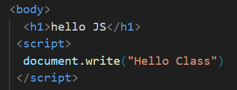

1.2 Write JS in external file

- Create JS in a folder
- Connect JS in external file to HTML

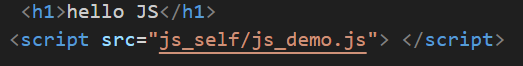

### 5. JavaScript Basics

#### 5.1 Variables

Variables are used to store values: `const`, `var`, `let`,

- The 'var' was used in JS from 1995 to 2015, now should only be used in code for older browsers
- The 'let' and 'const' was added to JS in 2015
- Always use `const` if the value should not be changed

The variables

- can not be a reserved keys
- should be meaningful
- can not start with a number
- can not contain a space a hyphen
- are case sensative

#### 5.3 Type of Variables

- Numeric
- String
- Boolean
- Null

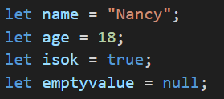

### 6. Objects in JS

[figure not shown]

### Exercise 3: Create a object

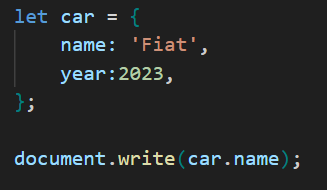

### 7. Array

- An array is a data structure that allows you to store multiple values in a single variable
- Arrays are useful for managing lists of items, such as numbers, strings, or objects.

#### 7.1 Declaring an Array

You can create an array using the [] syntax or the Array() constructor.

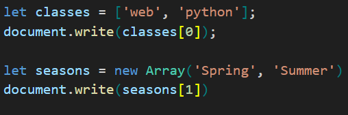

### 8. Function

A JS function is a reusable block of code designed to perform a particular task

Functions allow developers to organize the reuse code efficiently

#### 8.1 Function Declaration

1. Function format

function name(parameter1, parameter2,...){

**code to be executed**

}

2. Call function

name();

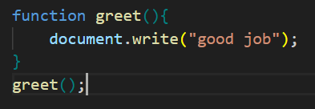

#### 8.2 Embed function into element

- Embedding a function into an HTML element in JavaScript involves setting up event handlers that call a function when the user interacts with the element.
- This allows you to dynamically change or update the content or behavior of the webpage based on user actions.

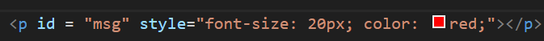

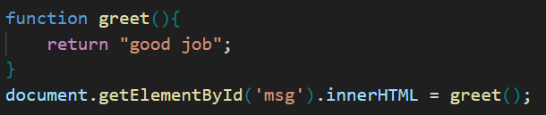